# Assignment 2: k-NN Classification

Conor Mangan

2026-09-30

# Introduction

The purpose of this analysis is to use k-nearest neighbors (k-NN) classification to predict whether a Universal Bank customer will accept a personal loan offer. The dataset contains information on 5,000 customers, including demographic characteristics, their relationship with the bank, and their response to a previous personal loan campaign. The response variable is Personal Loan, where a value of 1 indicates that the customer accepted the personal loan offer and a value of 0 indicates that the customer did not accept the offer.

```r
knitr::opts_chunk$set(echo = TRUE)

library(caret)
library(class)
library(dplyr)

set.seed(1)
```

# Load and Examine the Data

The Universal Bank dataset is imported and examined below.

```r
bank <- read.csv("UniversalBank.csv")

head(bank)
```

```
##   ID Age Experience Income ZIP.Code Family CCAvg Education Mortgage
## 1  1  25          1     49    91107      4   1.6         1        0
## 2  2  45         19     34    90089      3   1.5         1        0
## 3  3  39         15     11    94720      1   1.0         1        0
## 4  4  35          9    100    94112      1   2.7         2        0
## 5  5  35          8     45    91330      4   1.0         2        0
## 6  6  37         13     29    92121      4   0.4         2      155
##   Personal.Loan Securities.Account CD.Account Online CreditCard
## 1             0                  1          0      0          0
## 2             0                  1          0      0          0
## 3             0                  0          0      0          0
## 4             0                  0          0      0          0
## 5             0                  0          0      0          1
## 6             0                  0          0      1          0
```

```r
dim(bank)
```

```
## [1] 5000   14
```

```r
str(bank)
```

```
## 'data.frame':    5000 obs. of  14 variables:
##  $ ID                : int  1 2 3 4 5 6 7 8 9 10 ...
##  $ Age               : int  25 45 39 35 35 37 53 50 35 34 ...
##  $ Experience        : int  1 19 15 9 8 13 27 24 10 9 ...
##  $ Income            : int  49 34 11 100 45 29 72 22 81 180 ...
##  $ ZIP.Code          : int  91107 90089 94720 94112 91330 92121 91711 93943 90089 93023 ...
##  $ Family            : int  4 3 1 1 4 4 2 1 3 1 ...
##  $ CCAvg             : num  1.6 1.5 1 2.7 1 0.4 1.5 0.3 0.6 8.9 ...
##  $ Education         : int  1 1 1 2 2 2 2 3 2 3 ...
##  $ Mortgage          : int  0 0 0 0 0 155 0 0 104 0 ...
##  $ Personal.Loan     : int  0 0 0 0 0 0 0 0 0 1 ...
##  $ Securities.Account: int  1 1 0 0 0 0 0 0 0 0 ...
##  $ CD.Account        : int  0 0 0 0 0 0 0 0 0 0 ...
##  $ Online            : int  0 0 0 0 0 1 1 0 1 0 ...
##  $ CreditCard        : int  0 0 0 0 1 0 0 1 0 0 ...
```

```r
table(bank$Personal.Loan)
```

```
##
##    0    1
## 4520  480
```

The dataset contains 5,000 customers. Of these customers, 480 accepted the previous personal loan offer, representing 9.6% of the observations.

# Data Preparation

The ID and ZIP Code variables are not used as predictors. Education has three categories, so it is transformed into three dummy variables before performing k-NN classification.

```r
bank$Education_1 <- ifelse(bank$Education == 1, 1, 0)
bank$Education_2 <- ifelse(bank$Education == 2, 1, 0)
bank$Education_3 <- ifelse(bank$Education == 3, 1, 0)

bank_knn <- bank %>%
  select(
    Age,
    Experience,
    Income,
    Family,
    CCAvg,
    Education_1,
    Education_2,
    Education_3,
    Mortgage,
    Securities.Account,
    CD.Account,
    Online,
    CreditCard,
    Personal.Loan
  )

head(bank_knn)
```

```
##   Age Experience Income Family CCAvg Education_1 Education_2 Education_3
## 1  25          1     49      4   1.6           1           0           0
## 2  45         19     34      3   1.5           1           0           0
## 3  39         15     11      1   1.0           1           0           0
## 4  35          9    100      1   2.7           0           1           0
## 5  35          8     45      4   1.0           0           1           0
## 6  37         13     29      4   0.4           0           1           0
##   Mortgage Securities.Account CD.Account Online CreditCard Personal.Loan
## 1        0                  1          0      0          0             0
## 2        0                  1          0      0          0             0
## 3        0                  0          0      0          0             0
## 4        0                  0          0      0          0             0
## 5        0                  0          0      0          1             0
## 6      155                  0          0      1          0             0
```

# Question 1

The data are first partitioned into 60% training and 40% validation sets. A random seed is specified so that the partition can be reproduced.

```r
set.seed(1)

train_index <- createDataPartition(
  bank_knn$Personal.Loan,
  p = 0.60,
  list = FALSE
)

train_data <- bank_knn[train_index, ]
valid_data <- bank_knn[-train_index, ]

nrow(train_data)
```

```
## [1] 3000
```

```r
nrow(valid_data)
```

```
## [1] 2000
```

The predictor variables and response variable are separated.

```r
train_x <- train_data %>%
  select(-Personal.Loan)

valid_x <- valid_data %>%
  select(-Personal.Loan)

train_y <- train_data$Personal.Loan
valid_y <- valid_data$Personal.Loan
```

Because k-NN relies on distances between observations, the predictor variables are standardized. The standardization parameters are estimated using only the training data and are then applied to the validation data.

```r
preprocess <- preProcess(
  train_x,
  method = c("center", "scale")
)

train_x_norm <- predict(preprocess, train_x)
valid_x_norm <- predict(preprocess, valid_x)
```

The customer specified in the assignment is created below.

```r
new_customer <- data.frame(
  Age = 40,
  Experience = 10,
  Income = 84,
  Family = 2,
  CCAvg = 2,
  Education_1 = 0,
  Education_2 = 1,
  Education_3 = 0,
  Mortgage = 0,
  Securities.Account = 0,
  CD.Account = 0,
  Online = 1,
  CreditCard = 1
)

new_customer_norm <- predict(preprocess, new_customer)
```

A k-NN model with k = 1 is used to classify the customer.

```r
set.seed(1)

prediction_k1 <- knn(
  train = train_x_norm,
  test = new_customer_norm,
  cl = train_y,
  k = 1
)

prediction_k1
```

```
## [1] 0
## Levels: 0 1
```

### Question 1 Interpretation

Using k = 1, the customer was classified as **0**. A classification of 1 indicates that the customer is predicted to accept the personal loan offer, while a classification of 0 indicates that the customer is predicted not to accept the personal loan offer.

# Question 2

To determine an appropriate value of k, values from 1 through 30 are evaluated using the validation data. Validation accuracy is calculated for each value.

```r
k_values <- 1:30
accuracy_values <- numeric(length(k_values))

for (i in seq_along(k_values)) {

  pred <- knn(
    train = train_x_norm,
    test = valid_x_norm,
    cl = train_y,
    k = k_values[i]
  )

  accuracy_values[i] <- mean(pred == valid_y)
}

results <- data.frame(
  k = k_values,
  Accuracy = accuracy_values
)

results
```

```
##     k Accuracy
## 1   1   0.9630
## 2   2   0.9585
## 3   3   0.9640
## 4   4   0.9575
## 5   5   0.9605
## 6   6   0.9580
## 7   7   0.9580
## 8   8   0.9570
## 9   9   0.9535
## 10 10   0.9525
## 11 11   0.9495
## 12 12   0.9495
## 13 13   0.9500
## 14 14   0.9505
```

[output cut: 16 more lines]

The value of k with the highest validation accuracy is identified.

```r
best_k <- results$k[which.max(results$Accuracy)]
best_accuracy <- max(results$Accuracy)

best_k
```

```
## [1] 3
```

```r
best_accuracy
```

```
## [1] 0.964
```

Validation accuracy across the different values of k is displayed graphically.

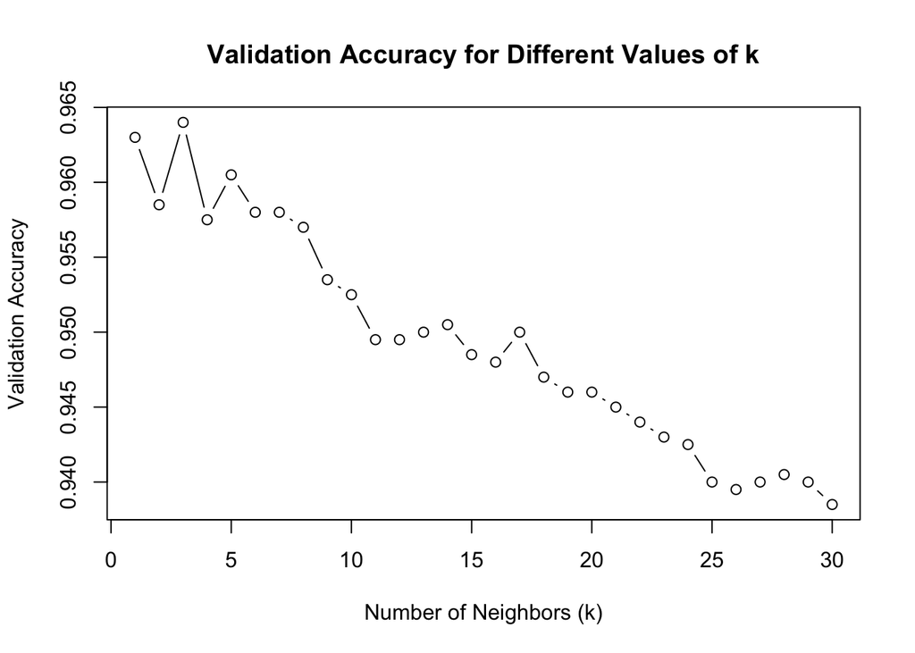

```r
plot(
  results$k,
  results$Accuracy,
  type = "b",
  xlab = "Number of Neighbors (k)",
  ylab = "Validation Accuracy",
  main = "Validation Accuracy for Different Values of k"
)
```

### Question 2 Interpretation

Very small values of k can lead to overfitting because predictions depend on only a small number of neighboring observations. Conversely, very large values of k can ignore useful local patterns in the predictor information. Based on the validation results, the selected value is **k = 3**, which produced a validation accuracy of **96.4%**.

# Question 3

The selected value of k is now used to classify the observations in the validation set. The resulting confusion matrix is shown below.

```r
best_pred_valid <- knn(
  train = train_x_norm,
  test = valid_x_norm,
  cl = train_y,
  k = best_k
)

cm_validation <- confusionMatrix(
  factor(best_pred_valid, levels = c(0, 1)),
  factor(valid_y, levels = c(0, 1)),
  positive = "1"
)

cm_validation
```

```
## Confusion Matrix and Statistics
##
##           Reference
## Prediction    0    1
##          0 1786   63
##          1    9  142
##
##                Accuracy : 0.964
##                  95% CI : (0.9549, 0.9717)
##     No Information Rate : 0.8975
##     P-Value [Acc > NIR] : < 2.2e-16
##
##                   Kappa : 0.7785
##
##  Mcnemar's Test P-Value : 4.208e-10
##
##             Sensitivity : 0.6927
##             Specificity : 0.9950
##          Pos Pred Value : 0.9404
##          Neg Pred Value : 0.9659
##              Prevalence : 0.1025
##          Detection Rate : 0.0710
##    Detection Prevalence : 0.0755
##       Balanced Accuracy : 0.8438
##
##        'Positive' Class : 1
##
```

### Question 3 Interpretation

The confusion matrix compares the predicted personal loan classifications with the actual outcomes in the validation data. Correct predictions appear along the diagonal of the matrix, while false positives and false negatives appear off the diagonal. Because only a relatively small percentage of customers accepted the previous personal loan offer, both overall accuracy and the model’s ability to identify customers in the acceptance class should be considered when evaluating performance.

# Question 4

The customer from Question 1 is classified again using the selected value of k.

```r
prediction_best_k <- knn(
  train = train_x_norm,
  test = new_customer_norm,
  cl = train_y,
  k = best_k
)

prediction_best_k
```

```
## [1] 0
## Levels: 0 1
```

### Question 4 Interpretation

Using **k = 3**, the customer is classified as **0**. A classification of 1 indicates predicted acceptance of the personal loan offer, while a classification of 0 indicates predicted non-acceptance.

# Question 5

The data are now repartitioned into 50% training, 30% validation, and 20% test sets. The same value of k selected previously is used for this analysis.

```r
set.seed(1)

train_index2 <- createDataPartition(
  bank_knn$Personal.Loan,
  p = 0.50,
  list = FALSE
)

train2 <- bank_knn[train_index2, ]
remaining <- bank_knn[-train_index2, ]

valid_index2 <- createDataPartition(
  remaining$Personal.Loan,
  p = 0.60,
  list = FALSE
)

valid2 <- remaining[valid_index2, ]
test2 <- remaining[-valid_index2, ]

nrow(train2)
```

```
## [1] 2500
```

```r
nrow(valid2)
```

```
## [1] 1500
```

```r
nrow(test2)
```

```
## [1] 1000
```

The predictor and response variables are separated for each partition.

```r
train2_x <- train2 %>%
  select(-Personal.Loan)

valid2_x <- valid2 %>%
  select(-Personal.Loan)

test2_x <- test2 %>%
  select(-Personal.Loan)

train2_y <- train2$Personal.Loan
valid2_y <- valid2$Personal.Loan
test2_y <- test2$Personal.Loan
```

The predictors are standardized using the training data.

```r
preprocess2 <- preProcess(
  train2_x,
  method = c("center", "scale")
)

train2_norm <- predict(preprocess2, train2_x)
valid2_norm <- predict(preprocess2, valid2_x)
test2_norm <- predict(preprocess2, test2_x)
```

Predictions are generated for the training, validation, and test sets using the previously selected value of k.

```r
pred_train2 <- knn(
  train = train2_norm,
  test = train2_norm,
  cl = train2_y,
  k = best_k
)

pred_valid2 <- knn(
  train = train2_norm,
  test = valid2_norm,
  cl = train2_y,
  k = best_k
)

pred_test2 <- knn(
  train = train2_norm,
  test = test2_norm,
  cl = train2_y,
  k = best_k
)
```

## Training Confusion Matrix

```r
cm_train <- confusionMatrix(
  factor(pred_train2, levels = c(0, 1)),
  factor(train2_y, levels = c(0, 1)),
  positive = "1"
)

cm_train
```

```
## Confusion Matrix and Statistics
##
##           Reference
## Prediction    0    1
##          0 2263   54
##          1    5  178
##
##                Accuracy : 0.9764
##                  95% CI : (0.9697, 0.982)
##     No Information Rate : 0.9072
##     P-Value [Acc > NIR] : < 2.2e-16
##
##                   Kappa : 0.8452
##
##  Mcnemar's Test P-Value : 4.129e-10
##
##             Sensitivity : 0.7672
##             Specificity : 0.9978
##          Pos Pred Value : 0.9727
##          Neg Pred Value : 0.9767
##              Prevalence : 0.0928
##          Detection Rate : 0.0712
##    Detection Prevalence : 0.0732
##       Balanced Accuracy : 0.8825
##
##        'Positive' Class : 1
##
```

## Validation Confusion Matrix

```r
cm_valid2 <- confusionMatrix(
  factor(pred_valid2, levels = c(0, 1)),
  factor(valid2_y, levels = c(0, 1)),
  positive = "1"
)

cm_valid2
```

```
## Confusion Matrix and Statistics
##
##           Reference
## Prediction    0    1
##          0 1358   42
##          1    6   94
##
##                Accuracy : 0.968
##                  95% CI : (0.9578, 0.9763)
##     No Information Rate : 0.9093
##     P-Value [Acc > NIR] : < 2.2e-16
##
##                   Kappa : 0.7797
##
##  Mcnemar's Test P-Value : 4.376e-07
##
##             Sensitivity : 0.69118
##             Specificity : 0.99560
##          Pos Pred Value : 0.94000
##          Neg Pred Value : 0.97000
##              Prevalence : 0.09067
##          Detection Rate : 0.06267
##    Detection Prevalence : 0.06667
##       Balanced Accuracy : 0.84339
##
##        'Positive' Class : 1
##
```

## Test Confusion Matrix

```r
cm_test <- confusionMatrix(
  factor(pred_test2, levels = c(0, 1)),
  factor(test2_y, levels = c(0, 1)),
  positive = "1"
)

cm_test
```

```
## Confusion Matrix and Statistics
##
##           Reference
## Prediction   0   1
##          0 884  35
##          1   4  77
##
##                Accuracy : 0.961
##                  95% CI : (0.9471, 0.9721)
##     No Information Rate : 0.888
##     P-Value [Acc > NIR] : < 2.2e-16
##
##                   Kappa : 0.777
##
##  Mcnemar's Test P-Value : 1.556e-06
##
##             Sensitivity : 0.6875
##             Specificity : 0.9955
##          Pos Pred Value : 0.9506
##          Neg Pred Value : 0.9619
##              Prevalence : 0.1120
##          Detection Rate : 0.0770
##    Detection Prevalence : 0.0810
##       Balanced Accuracy : 0.8415
##
##        'Positive' Class : 1
##
```

The overall accuracy for each partition is extracted below to make the results easier to compare.

```r
train_accuracy <- cm_train$overall["Accuracy"]
valid_accuracy <- cm_valid2$overall["Accuracy"]
test_accuracy <- cm_test$overall["Accuracy"]

accuracy_comparison <- data.frame(
  Data_Set = c("Training", "Validation", "Test"),
  Accuracy = c(
    train_accuracy,
    valid_accuracy,
    test_accuracy
  )
)

accuracy_comparison
```

```
##     Data_Set Accuracy
## 1   Training   0.9764
## 2 Validation   0.9680
## 3       Test   0.9610
```

### Question 5 Interpretation

Using **k = 3**, the training set produced an accuracy of **97.64%**, the validation set produced an accuracy of **96.8%**, and the test set produced an accuracy of **96.1%**.

Differences among the three confusion matrices are expected because each partition contains different observations. The training observations are directly involved in constructing the k-NN classifier, whereas the validation and test observations provide an evaluation of the model on observations that were not used to construct the classifier. Similar performance between the validation and test sets would indicate that the model generalizes reasonably well to new customers.

The class imbalance should also be considered when interpreting these results. Only 480 of the 5,000 customers, or 9.6%, accepted the personal loan in the previous campaign. Therefore, overall accuracy alone does not provide a complete picture of model performance, and the false positives, false negatives, sensitivity, and specificity shown in the confusion matrices are also useful for evaluating the classifier.

# Conclusion

This analysis applied k-nearest neighbors classification to the Universal Bank customer data to predict personal loan acceptance. The model was initially evaluated using a 60% training and 40% validation partition, and different values of k were compared to select an appropriate number of neighbors. The selected model was then used to classify the specified customer and was further evaluated using training, validation, and test sets. The confusion matrices provide information about both correct and incorrect classifications and help evaluate how well the k-NN model may generalize to new customers.